# R Notebook - Case Study 2

**Objective**

We have been hired by the **DDSAnalytics** that specializes in talent management solutions for Fortune 100 companies, with the objective of predicting employee turnover using the existing employee data. These objectives include: 1. identify top 3 factors that lead to attrition 2. job role specific treands *(e.g., highest job satisfaction)* 3. build a model to predict attrition

**Executive Summary** In summary to the objective, we found:

- Employee attrition– whre employees that were most likely to turnover are those that (1) most importantly workovertime and (2) have lower salaries. Also, we saw decreased in job involvement and increased time_till_promotion.
- In terms of monthly income – Job Role and Job Level were key to predicting salary
- Age and Gender – Good news! Yall are on the right track with employee management as both Age and Gender were not significant factors or indicators used in the models. We would indicate that there is a slight tendacy for those younger in age to be more likely to leave. This was appartent in the Employee attrition model werhe maritial status = single, but Age itself was not a key factor. Contrary to other industries, the dataset provided indicated no significant indication gender was a key factor in turnover or a wage gap.

```r
library(caret)
library(class)
library(fastDummies) # https://cran.r-project.org/web/packages/fastDummies/vignettes/making-dummy-variables.html
library(data.table)
df = read.csv("./data/casestudy2data.csv")
str(df)
```

```
## 'data.frame':    870 obs. of  36 variables:
##  $ ID                      : int  1 2 3 4 5 6 7 8 9 10 ...
##  $ Age                     : int  32 40 35 32 24 27 41 37 34 34 ...
##  $ Attrition               : Factor w/ 2 levels "No","Yes": 1 1 1 1 1 1 1 1 1 1 ...
##  $ BusinessTravel          : Factor w/ 3 levels "Non-Travel","Travel_Frequently",..: 3 3 2 3 2 2 3 3 3 2 ...
##  $ DailyRate               : int  117 1308 200 801 567 294 1283 309 1333 653 ...
##  $ Department              : Factor w/ 3 levels "Human Resources",..: 3 2 2 3 2 2 2 3 3 2 ...
##  $ DistanceFromHome        : int  13 14 18 1 2 10 5 10 10 10 ...
##  $ Education               : int  4 3 2 4 1 2 5 4 4 4 ...
##  $ EducationField          : Factor w/ 6 levels "Human Resources",..: 2 4 2 3 6 2 4 2 2 6 ...
##  $ EmployeeCount           : int  1 1 1 1 1 1 1 1 1 1 ...
##  $ EmployeeNumber          : int  859 1128 1412 2016 1646 733 1448 1105 1055 1597 ...
##  $ EnvironmentSatisfaction : int  2 3 3 3 1 4 2 4 3 4 ...
##  $ Gender                  : Factor w/ 2 levels "Female","Male": 2 2 2 1 1 2 2 1 1 2 ...
##  $ HourlyRate              : int  73 44 60 48 32 32 90 88 87 92 ...
```

[output cut: 22 more lines]

From the above output of the current dataset characteristics, we have 870 observations (rows of employees) and 36 variable. In efforts to predict employee turnover, we will utilize the `Attrition` factor as our response variable and the remaining variables as canidate predictor variables.

Next we explore to see if therea re missing values in the data set.

```r
sapply(df, function(x) sum(is.na(x)))
```

```
##                       ID                      Age                Attrition
##                        0                        0                        0
##           BusinessTravel                DailyRate               Department
##                        0                        0                        0
##         DistanceFromHome                Education           EducationField
##                        0                        0                        0
##            EmployeeCount           EmployeeNumber  EnvironmentSatisfaction
##                        0                        0                        0
##                   Gender               HourlyRate           JobInvolvement
##                        0                        0                        0
##                 JobLevel                  JobRole          JobSatisfaction
##                        0                        0                        0
##            MaritalStatus            MonthlyIncome              MonthlyRate
##                        0                        0                        0
##       NumCompaniesWorked                   Over18                 OverTime
##                        0                        0                        0
##        PercentSalaryHike        PerformanceRating RelationshipSatisfaction
##                        0                        0                        0
##            StandardHours         StockOptionLevel        TotalWorkingYears
##                        0                        0                        0
##    TrainingTimesLastYear          WorkLifeBalance           YearsAtCompany
##                        0                        0                        0
##       YearsInCurrentRole  YearsSinceLastPromotion     YearsWithCurrManager
##                        0                        0                        0
```

There does not appear to be any missing variables that we have to handel.

Next we do some exploration on the leangh of time employees spend at the company

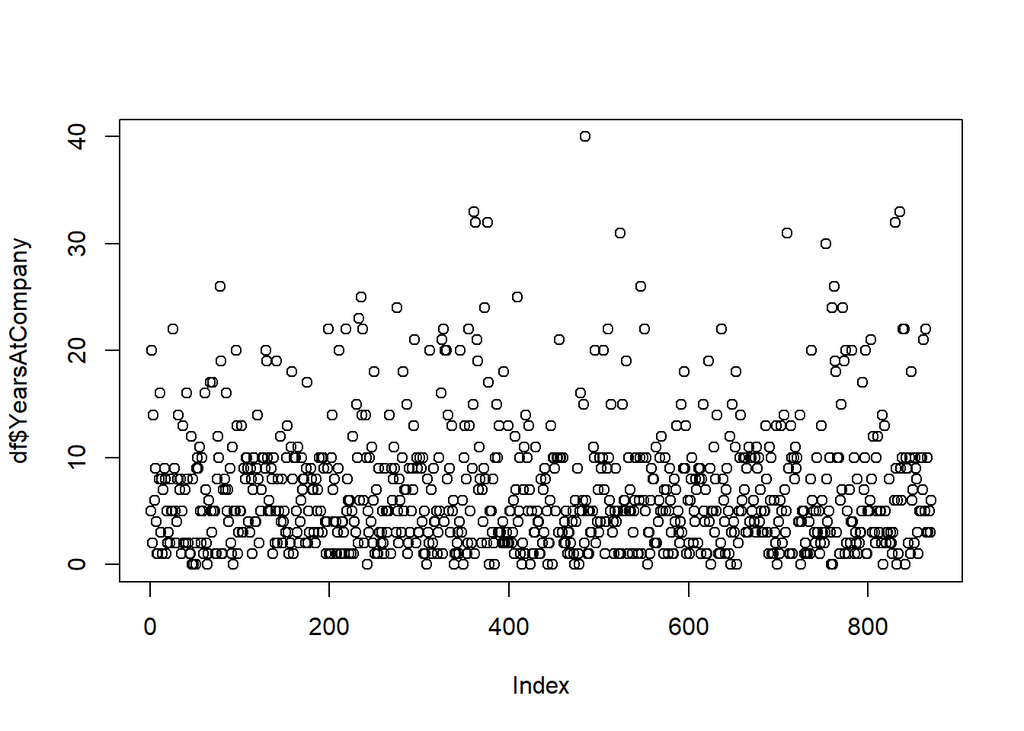

```
##    Min. 1st Qu.  Median    Mean 3rd Qu.    Max.
##   0.000   3.000   5.000   6.962  10.000  40.000
```

```r
plot(df$YearsAtCompany);summary(df$YearsAtCompany)
```

it appears employees typically spend around 5-7 years at Telnet.

drop columns we dont need

```r
columns_to_drop = c("ID", "EmployeeNumber", "Over18", "StandardHours", "EmployeeCount" )
df = df[,!(names(df) %in% columns_to_drop)]
```

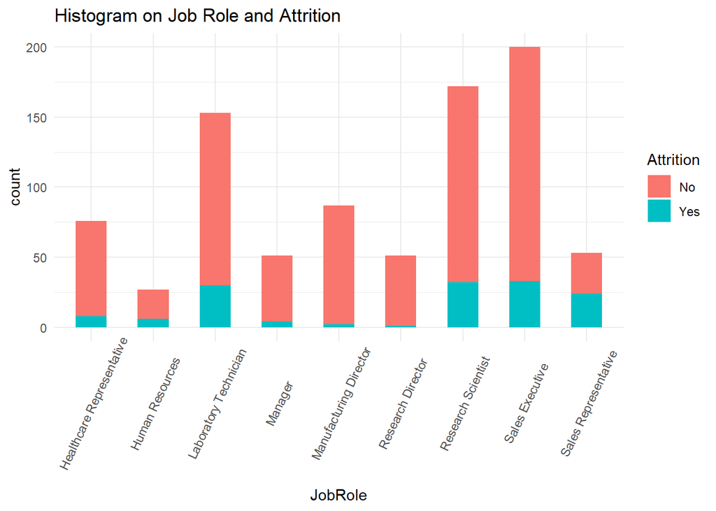

```r
library(ggplot2)
theme_set(theme_minimal())  # pre-set the bw theme.
# inspiration - http://r-statistics.co/Top50-Ggplot2-Visualizations-MasterList-R-Code.html

g <- ggplot(df, aes(JobRole))
g + geom_bar(aes(fill=Attrition), width = 0.5) +
  theme(axis.text.x = element_text(angle=65, vjust=0.6)) +
  labs(title="Histogram on Job Role and Attrition")
```

looks like we should do a log transformaiton

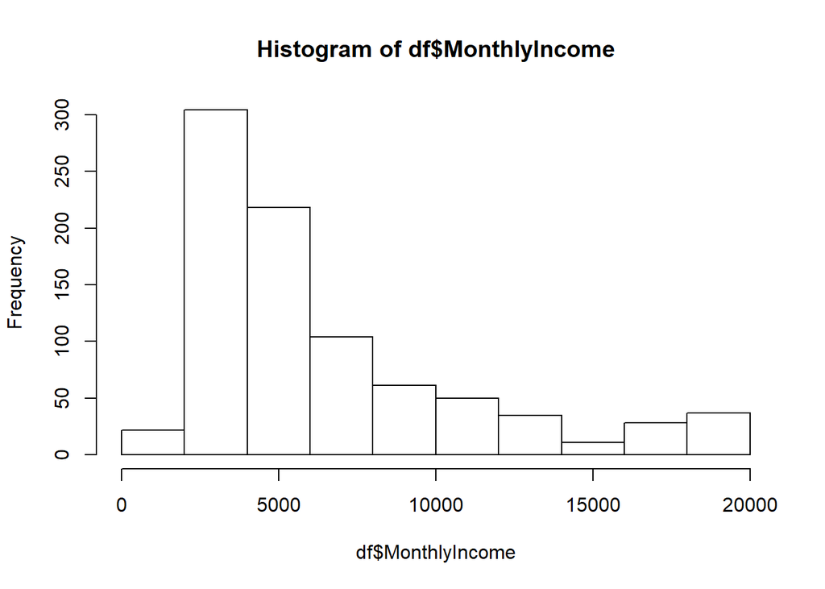

```r
hist(df$MonthlyIncome)
```

**log Trasformaitons**

```r
#attach(df)
df$Attrition <- factor(df$Attrition)
df$MonthlyIncome = log(df$MonthlyIncome)
df$Attrition = as.numeric(as.factor(df$Attrition))-1
```

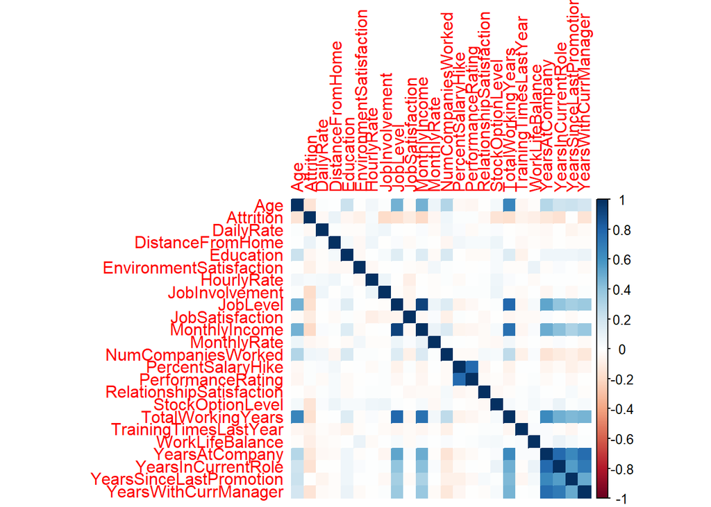

```r
library(corrplot)
number_variables = sapply(df, is.numeric)
corrmatrix =  cor(df[,number_variables], )
#top = colnames(corrmatrix)[apply(corrmatrix, 1, function (x) which(x==max(x[abs(x)>.9])))]
#corrmatrix =  cor(df[,top], )
corrplot(corrmatrix, method="color")
```

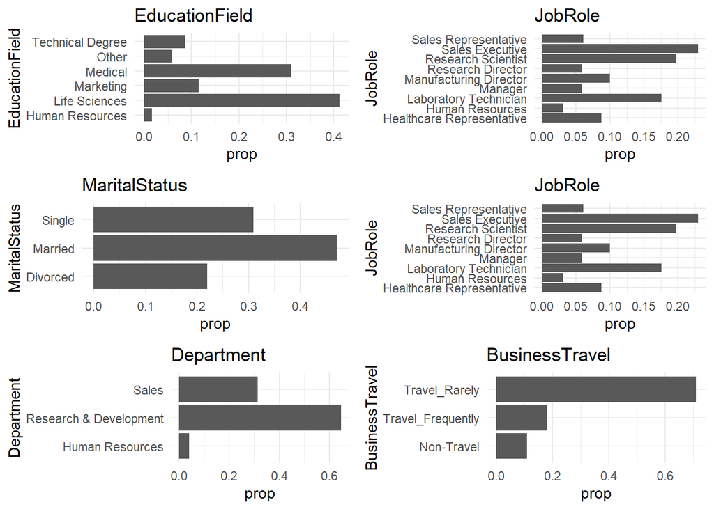

```r
library(gridExtra)
library(ggplot2)

# https://stackoverflow.com/questions/19835987/display-frequency-instead-of-count-with-geom-bar-in-ggplot

graph1= ggplot(df, aes(x=EducationField)) +
  geom_bar(aes(y = ..prop.., group=1)) +
  ggtitle("EducationField") +
  xlab("EducationField") +
  coord_flip()

graph2= ggplot(df, aes(x=JobRole)) +
  geom_bar(aes(y = ..prop.., group=1)) +
  ggtitle("JobRole") +
  xlab("JobRole") +
  coord_flip()

graph3 = ggplot(df, aes(x=MaritalStatus)) +
  geom_bar(aes(y = ..prop.., group=1)) +
  ggtitle("MaritalStatus") +
  xlab("MaritalStatus") +
  coord_flip()


graph4 = ggplot(df, aes(x=JobRole)) +
  geom_bar(aes(y = ..prop.., group=1)) +
  ggtitle("JobRole") +
  xlab("JobRole") +
  coord_flip()

graph5 = ggplot(df, aes(x=Department)) +
  geom_bar(aes(y = ..prop.., group=1)) +
  ggtitle("Department") +
  xlab("Department") +
  coord_flip()

graph6 = ggplot(df, aes(x=BusinessTravel)) +
  geom_bar(aes(y = ..prop.., group=1)) +
  ggtitle("BusinessTravel") +
  xlab("BusinessTravel") +
  coord_flip()

grid.arrange(graph1, graph2, graph3, graph4,
             graph5, graph6, ncol=2)
```

# Model Fitting

```r
stepwise = step(glm(Attrition ~ ., data=df, family = binomial(link="logit")), trace=0, direction='both',test="Chisq")
formula(stepwise)
```

```
## Attrition ~ Age + BusinessTravel + DistanceFromHome + EnvironmentSatisfaction +
##     HourlyRate + JobInvolvement + JobLevel + JobRole + JobSatisfaction +
##     MaritalStatus + MonthlyIncome + NumCompaniesWorked + OverTime +
##     RelationshipSatisfaction + TotalWorkingYears + TrainingTimesLastYear +
##     WorkLifeBalance + YearsSinceLastPromotion + YearsWithCurrManager
```

```r
summary(stepwise)
```

```
##
## Call:
## glm(formula = Attrition ~ Age + BusinessTravel + DistanceFromHome +
##     EnvironmentSatisfaction + HourlyRate + JobInvolvement + JobLevel +
##     JobRole + JobSatisfaction + MaritalStatus + MonthlyIncome +
##     NumCompaniesWorked + OverTime + RelationshipSatisfaction +
##     TotalWorkingYears + TrainingTimesLastYear + WorkLifeBalance +
##     YearsSinceLastPromotion + YearsWithCurrManager, family = binomial(link = "logit"),
##     data = df)
##
## Deviance Residuals:
##     Min       1Q   Median       3Q      Max
## -2.0173  -0.4632  -0.2202  -0.0705   3.3173
##
## Coefficients:
##                                  Estimate Std. Error z value Pr(>|z|)
## (Intercept)                     11.088351   4.079010   2.718 0.006560 **
## Age                             -0.032766   0.017965  -1.824 0.068170 .
## BusinessTravelTravel_Frequently  1.618952   0.509876   3.175 0.001497 **
## BusinessTravelTravel_Rarely      0.845321   0.449619   1.880 0.060097 .
## DistanceFromHome                 0.043133   0.014463   2.982 0.002862 **
## EnvironmentSatisfaction         -0.363851   0.113925  -3.194 0.001404 **
## HourlyRate                       0.010268   0.006059   1.695 0.090129 .
## JobInvolvement                  -0.825085   0.168587  -4.894 9.87e-07 ***
## JobLevel                         0.696019   0.368020   1.891 0.058591 .
## JobRoleHuman Resources           1.306064   0.795066   1.643 0.100443
## JobRoleLaboratory Technician     0.673905   0.608049   1.108 0.267729
## JobRoleManager                   0.289855   0.872439   0.332 0.739711
## JobRoleManufacturing Director   -1.752267   0.880287  -1.991 0.046529 *
## JobRoleResearch Director        -1.512073   1.245542  -1.214 0.224752
## JobRoleResearch Scientist        0.080825   0.608674   0.133 0.894361
## JobRoleSales Executive           0.616722   0.514728   1.198 0.230858
## JobRoleSales Representative      1.626529   0.677367   2.401 0.016339 *
## JobSatisfaction                 -0.484924   0.110709  -4.380 1.19e-05 ***
## MaritalStatusMarried             0.901412   0.388193   2.322 0.020229 *
## MaritalStatusSingle              1.823928   0.394017   4.629 3.67e-06 ***
## MonthlyIncome                   -1.152255   0.505114  -2.281 0.022538 *
## NumCompaniesWorked               0.239463   0.051932   4.611 4.01e-06 ***
## OverTimeYes                      2.000185   0.257612   7.764 8.21e-15 ***
## RelationshipSatisfaction        -0.261765   0.107224  -2.441 0.014635 *
## TotalWorkingYears               -0.088755   0.038156  -2.326 0.020011 *
## TrainingTimesLastYear           -0.278798   0.102396  -2.723 0.006474 **
## WorkLifeBalance                 -0.589550   0.166949  -3.531 0.000413 ***
## YearsSinceLastPromotion          0.265936   0.053661   4.956 7.20e-07 ***
## YearsWithCurrManager            -0.151156   0.053649  -2.818 0.004840 **
## ---
## Signif. codes:  0 '***' 0.001 '**' 0.01 '*' 0.05 '.' 0.1 ' ' 1
##
## (Dispersion parameter for binomial family taken to be 1)
##
##     Null deviance: 767.67  on 869  degrees of freedom
## Residual deviance: 476.02  on 841  degrees of freedom
## AIC: 534.02
##
## Number of Fisher Scoring iterations: 7
```

**test train split**

```r
smp_size <- floor(0.7 * nrow(df))

## set the seed to make your partition reproducible
set.seed(123)
train_ind <- sample(seq_len(nrow(df)), size = smp_size)

train = df[train_ind,]
test =  df[-train_ind,]
dim(train)
```

```
## [1] 609  31
```

```r
dim(test)
```

```
## [1] 261  31
```

### Logistic Model

after several stepwise regression and model selection experiments…

```r
logit_model <- glm(Attrition ~ OverTime+MonthlyIncome + MaritalStatus + JobInvolvement+JobRole ,
                   family=binomial(link="logit"),data=train)
logit_pred = predict(logit_model, newdata=test, type='response')
logit_pred = ifelse(logit_pred > 0.5 ,1,0)
print(summary(logit_model))
```

```
##
## Call:
## glm(formula = Attrition ~ OverTime + MonthlyIncome + MaritalStatus +
##     JobInvolvement + JobRole, family = binomial(link = "logit"),
##     data = train)
##
## Deviance Residuals:
##     Min       1Q   Median       3Q      Max
## -1.7292  -0.5240  -0.3222  -0.1273   2.8045
##
## Coefficients:
##                                Estimate Std. Error z value Pr(>|z|)
## (Intercept)                     8.78374    3.65452   2.404 0.016238 *
## OverTimeYes                     1.89093    0.27193   6.954 3.56e-12 ***
## MonthlyIncome                  -1.34718    0.40551  -3.322 0.000893 ***
## MaritalStatusMarried            1.42309    0.48905   2.910 0.003616 **
## MaritalStatusSingle             1.82596    0.49134   3.716 0.000202 ***
## JobInvolvement                 -0.55672    0.18596  -2.994 0.002755 **
## JobRoleHuman Resources          0.33867    0.88777   0.381 0.702843
## JobRoleLaboratory Technician   -0.03698    0.65528  -0.056 0.954999
## JobRoleManager                  1.38778    0.86231   1.609 0.107536
## JobRoleManufacturing Director  -0.84400    0.90418  -0.933 0.350592
## JobRoleResearch Director      -14.09427  582.28701  -0.024 0.980689
## JobRoleResearch Scientist      -0.31556    0.65281  -0.483 0.628818
## JobRoleSales Executive          0.40743    0.57849   0.704 0.481248
## JobRoleSales Representative     0.76602    0.71632   1.069 0.284895
## ---
## Signif. codes:  0 '***' 0.001 '**' 0.01 '*' 0.05 '.' 0.1 ' ' 1
##
## (Dispersion parameter for binomial family taken to be 1)
##
##     Null deviance: 517.11  on 608  degrees of freedom
## Residual deviance: 381.31  on 595  degrees of freedom
## AIC: 409.31
##
## Number of Fisher Scoring iterations: 16
```

```r
cm = table(logit_pred,test$Attrition)
print(cm)
```

```
##
## logit_pred   0   1
##          0 210  34
##          1   3  14
```

```r
tn = cm[1]
fn = cm[2]
fp = cm[3]
tp = cm[4]




sensitivity = tp / (tp + fn)
specificity = tn / (tn + fp)
accuracy = (tp + tn) / (tp + tn + fp + fn)
misclassification_rate = 1 - accuracy

print(paste("sensitivity: ", round(sensitivity,2)))
```

```
## [1] "sensitivity:  0.82"
```

```r
print(paste("specificity: ", round(specificity,2)))
```

```
## [1] "specificity:  0.86"
```

```r
print(paste("accuracy: ", round(accuracy,2)))
```

```
## [1] "accuracy:  0.86"
```

```r
anova(logit_model,  test="Chisq")
```

|  | Df | Deviance | Resid. Df | Resid. Dev | Pr(>Chi) |
| --- | --- | --- | --- | --- | --- |
| NULL | NA | NA | 608 | 517.1092 | NA |
| OverTime | 1 | 48.641083 | 607 | 468.4681 | 3.073627e-12 |
| MonthlyIncome | 1 | 40.092092 | 606 | 428.3760 | 2.422678e-10 |
| MaritalStatus | 2 | 21.637263 | 604 | 406.7388 | 2.002295e-05 |
| JobInvolvement | 1 | 9.510983 | 603 | 397.2278 | 2.042457e-03 |
| JobRole | 8 | 15.913053 | 595 | 381.3147 | 4.364163e-02 |

[output not shown]

reviewing the coeficiencts output - all execpt JobRole are significant.

…ect..

the updated logistic regression model provided the following: - Sensitivity = 82% - specificity = 86% - Missclassificaiton rate = 14%

```r
submission_  = read.csv("./data/CaseStudy2CompSet No Attrition.csv")
submission_$MonthlyIncome = log(submission_$MonthlyIncome)

submission_pred = predict(logit_model, newdata=submission_, type='response')
submission_pred = ifelse(submission_pred > 0.5 ,"Yes","No")
final_submission = data.table(ID=submission_$ID, Attrition=submission_pred)
write.table(final_submission, "./data/Case2PredictionsPhillip Attrition.csv", sep=",", row.names=F)
```

## Random Forest

```r
library(randomForest)
#rf = randomForest(formula(stepwise), data = train,proximity=TRUE,mtry=2, importance=TRUE )
rf = randomForest(Attrition ~ OverTime+MonthlyIncome  +JobLevel+ MaritalStatus + TotalWorkingYears +StockOptionLevel + YearsWithCurrManager+YearsAtCompany + Age
                  , data = train,proximity=TRUE,mtry=2, importance=TRUE )
print(rf)
```

```
##
## Call:
##  randomForest(formula = Attrition ~ OverTime + MonthlyIncome +      JobLevel + MaritalStatus + TotalWorkingYears + StockOptionLevel +      YearsWithCurrManager + YearsAtCompany + Age, data = train,      proximity = TRUE, mtry = 2, importance = TRUE)
##                Type of random forest: regression
##                      Number of trees: 500
## No. of variables tried at each split: 2
##
##           Mean of squared residuals: 0.1115264
##                     % Var explained: 13.04
```

```r
rf_pred = predict(rf,newdata=test, type="class")
rf_pred = ifelse(rf_pred > 0.5,1,0)


cm = table(rf_pred, test$Attrition)
print(mean(rf_pred==test$Attrition))
```

```
## [1] 0.8505747
```

```r
print(cm)
```

```
##
## rf_pred   0   1
##       0 211  37
##       1   2  11
```

```r
tn = cm[1]
fn = cm[2]
fp = cm[3]
tp = cm[4]




sensitivity = tp / (tp + fn)
specificity = tn / (tn + fp)
accuracy = (tp + tn) / (tp + tn + fp + fn)
misclassification_rate = 1 - accuracy

print(paste("sensitivity: ", round(sensitivity,2)))
```

```
## [1] "sensitivity:  0.85"
```

```r
print(paste("specificity: ", round(specificity,2)))
```

```
## [1] "specificity:  0.85"
```

```r
print(paste("accuracy: ", round(accuracy,2)))
```

```
## [1] "accuracy:  0.85"
```

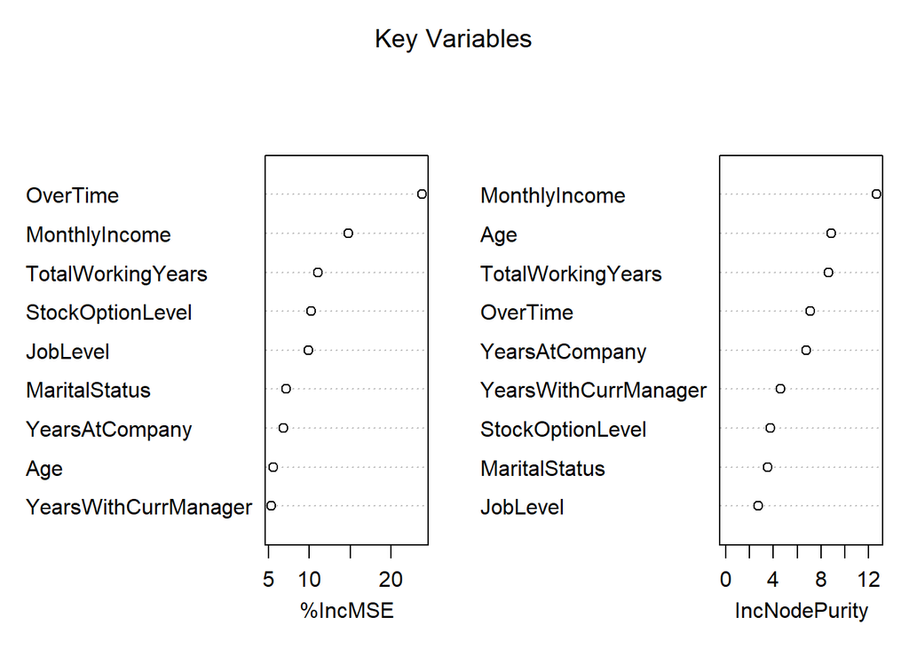

```r
#confusionMatrix(rf_pred, test_Attrition)

varImpPlot(rf, sort=T, n.var = 9, main = 'Key Variables')
```

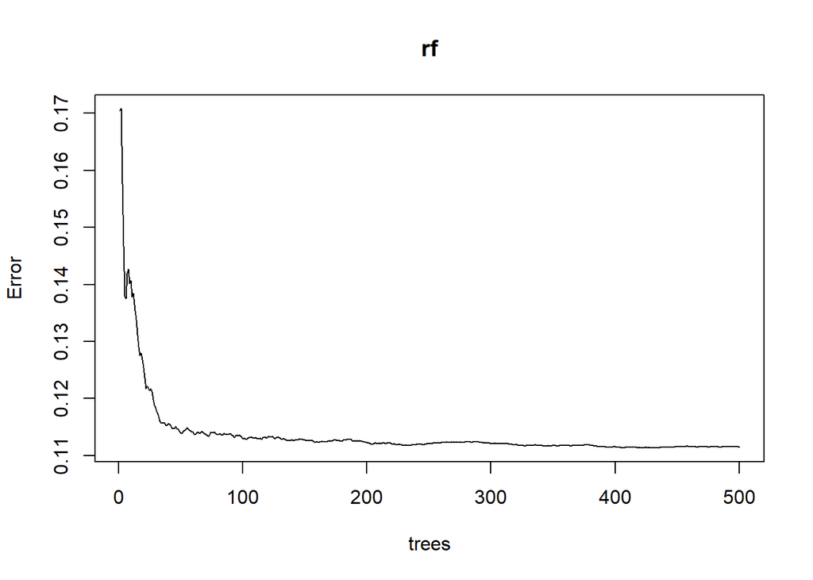

```r
plot(rf)
```

```r
# https://www.r-bloggers.com/variable-importance-plot-and-variable-selection/
(VI_F=importance(rf))
```

```
##                        %IncMSE IncNodePurity
## OverTime             23.836162      7.099323
## MonthlyIncome        14.787891     12.682604
## JobLevel              9.923178      2.747512
## MaritalStatus         7.159041      3.495974
## TotalWorkingYears    11.054809      8.653446
## StockOptionLevel     10.248559      3.745384
## YearsWithCurrManager  5.331003      4.606315
## YearsAtCompany        6.835828      6.757518
## Age                   5.559646      8.882013
```

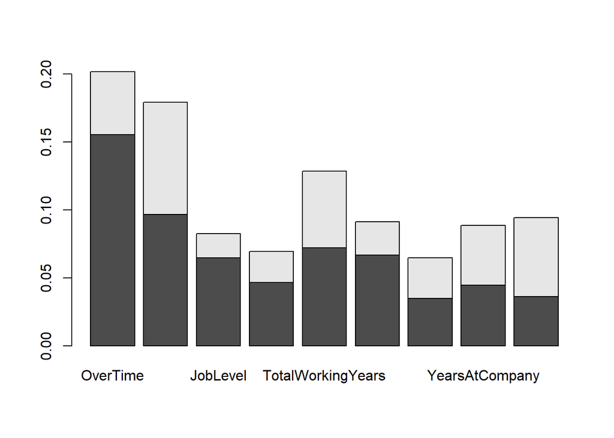

```r
barplot(t(VI_F/sum(VI_F)))
```

### KNN

```r
sepwise_variables = c("Attrition","Age","DistanceFromHome","JobInvolvement","JobLevel","JobSatisfaction",
    "MonthlyIncome","TotalWorkingYears","TrainingTimesLastYear",
    "WorkLifeBalance","YearsSinceLastPromotion","YearsWithCurrManager", "JobRole")
numerica_var = c("Attrition","Age","DistanceFromHome","JobInvolvement","JobLevel","JobSatisfaction",
    "MonthlyIncome","TotalWorkingYears","TrainingTimesLastYear",
    "WorkLifeBalance","YearsSinceLastPromotion","YearsWithCurrManager")

categorical_var = c("JobRole")

knn_df = df[,sepwise_variables]
knn_df = fastDummies::dummy_cols(knn_df, select_columns=categorical_var, remove_first_dummy=TRUE)
knn_df = knn_df[,!(names(knn_df) %in% categorical_var)]

colnames(knn_df)[which(colnames(knn_df) %in% c("JobRole_Manufacturing Director","JobRole_Research Director",
                                               "JobRole_Research Scientist","JobRole_Sales Representative",
                                               "JobRole_Healthcare Representative","JobRole_Human Resources",
                                               "JobRole_Laboratory Technician") )] <- c("role_manf_direc","role_director",
                                                            "role_science", "rolesales_rep", "role_healthrep",
                                                            "role_HR", "role_lab"
                                                                                                                )

knn_df$travel_freq = ifelse(df$BusinessTravel == "Travel_Frequently", 1, 0)
knn_df$male = ifelse(df$Gender == "Male", 1, 0)
knn_df$OT = ifelse(df$OverTime == "Yes", 1, 0)


paste(names(knn_df), collapse = " + ")
```

[output not shown]

_**test train**

```r
smp_size <- floor(0.7 * nrow(knn_df))

## set the seed to make your partition reproducible
set.seed(234)
train_ind <- sample(seq_len(nrow(knn_df)), size = smp_size, replace=FALSE)

train = knn_df[train_ind,]
test =  knn_df[-train_ind,]
dim(train)
```

```
## [1] 609  23
```

```r
dim(test)
```

```
## [1] 261  23
```

```r
k3 = knn(train,test,cl=train$Attrition,k=20)
confusionMatrix(table(test$Attrition,k3))
```

```
## Confusion Matrix and Statistics
##
##    k3
##       0   1
##   0 213   1
##   1  45   2
##
##                Accuracy : 0.8238
##                  95% CI : (0.772, 0.868)
##     No Information Rate : 0.9885
##     P-Value [Acc > NIR] : 1
##
##                   Kappa : 0.0597
##
##  Mcnemar's Test P-Value : 2.298e-10
##
##             Sensitivity : 0.82558
##             Specificity : 0.66667
##          Pos Pred Value : 0.99533
##          Neg Pred Value : 0.04255
##              Prevalence : 0.98851
##          Detection Rate : 0.81609
##    Detection Prevalence : 0.81992
##       Balanced Accuracy : 0.74612
##
##        'Positive' Class : 0
##
```

# Objective 2 Salary Prediction

```r
stepwise = step(glm(MonthlyIncome ~ ., data=df), direction='both', trace=0)
formula(stepwise)
```

```
## MonthlyIncome ~ Attrition + BusinessTravel + DailyRate + EnvironmentSatisfaction +
##     JobLevel + JobRole + NumCompaniesWorked + PerformanceRating +
##     RelationshipSatisfaction + TotalWorkingYears + YearsInCurrentRole
```

```r
summary(stepwise)
```

```
##
## Call:
## glm(formula = MonthlyIncome ~ Attrition + BusinessTravel + DailyRate +
##     EnvironmentSatisfaction + JobLevel + JobRole + NumCompaniesWorked +
##     PerformanceRating + RelationshipSatisfaction + TotalWorkingYears +
##     YearsInCurrentRole, data = df)
##
## Deviance Residuals:
##      Min        1Q    Median        3Q       Max
## -0.81581  -0.14118  -0.00372   0.13462   0.65445
##
## Coefficients:
##                                   Estimate Std. Error t value Pr(>|t|)
## (Intercept)                      7.915e+00  9.011e-02  87.837  < 2e-16 ***
## Attrition                       -5.298e-02  2.167e-02  -2.445  0.01467 *
## BusinessTravelTravel_Frequently  6.163e-02  2.941e-02   2.096  0.03641 *
## BusinessTravelTravel_Rarely      6.940e-02  2.477e-02   2.801  0.00520 **
## DailyRate                        2.686e-05  1.894e-05   1.418  0.15656
## EnvironmentSatisfaction         -1.559e-02  6.946e-03  -2.244  0.02509 *
## JobLevel                         3.658e-01  1.727e-02  21.184  < 2e-16 ***
## JobRoleHuman Resources          -3.323e-01  5.283e-02  -6.289 5.11e-10 ***
## JobRoleLaboratory Technician    -3.577e-01  3.549e-02 -10.077  < 2e-16 ***
## JobRoleManager                   1.104e-01  4.843e-02   2.279  0.02289 *
## JobRoleManufacturing Director    9.838e-04  3.525e-02   0.028  0.97774
## JobRoleResearch Director         1.912e-01  4.523e-02   4.228 2.61e-05 ***
## JobRoleResearch Scientist       -3.206e-01  3.554e-02  -9.020  < 2e-16 ***
## JobRoleSales Executive          -1.355e-02  3.029e-02  -0.447  0.65481
## JobRoleSales Representative     -4.117e-01  4.515e-02  -9.119  < 2e-16 ***
## NumCompaniesWorked               8.422e-03  3.292e-03   2.558  0.01070 *
## PerformanceRating               -3.221e-02  2.121e-02  -1.518  0.12934
## RelationshipSatisfaction        -1.235e-02  6.901e-03  -1.790  0.07380 .
## TotalWorkingYears                5.906e-03  1.865e-03   3.167  0.00159 **
## YearsInCurrentRole               9.266e-03  2.512e-03   3.688  0.00024 ***
## ---
## Signif. codes:  0 '***' 0.001 '**' 0.01 '*' 0.05 '.' 0.1 ' ' 1
##
## (Dispersion parameter for gaussian family taken to be 0.04939666)
##
##     Null deviance: 380.291  on 869  degrees of freedom
## Residual deviance:  41.987  on 850  degrees of freedom
## AIC: -126.13
##
## Number of Fisher Scoring iterations: 2
```

_**test train**

```r
df$TotalWorkingYears_log = log(df$TotalWorkingYears+0.5)

smp_size <- floor(0.7 * nrow(df))

## set the seed to make your partition reproducible
set.seed(123)
train_ind <- sample(seq_len(nrow(df)), size = smp_size)

train = df[train_ind,]
test =  df[-train_ind,]
dim(train)
```

```
## [1] 609  32
```

```r
dim(test)
```

```
## [1] 261  32
```

```r
lm_model <- lm(MonthlyIncome ~ JobLevel+JobRole+Attrition + TotalWorkingYears_log, data=train)
print(summary(lm_model))
```

```
##
## Call:
## lm(formula = MonthlyIncome ~ JobLevel + JobRole + Attrition +
##     TotalWorkingYears_log, data = train)
##
## Residuals:
##      Min       1Q   Median       3Q      Max
## -0.78663 -0.12992 -0.00552  0.13938  0.63414
##
## Coefficients:
##                                 Estimate Std. Error t value Pr(>|t|)
## (Intercept)                    7.6238504  0.0529685 143.932  < 2e-16 ***
## JobLevel                       0.3398712  0.0178295  19.062  < 2e-16 ***
## JobRoleHuman Resources        -0.2038213  0.0634266  -3.213  0.00138 **
## JobRoleLaboratory Technician  -0.3446976  0.0394489  -8.738  < 2e-16 ***
## JobRoleManager                 0.1551739  0.0536452   2.893  0.00396 **
## JobRoleManufacturing Director  0.0336344  0.0409945   0.820  0.41228
## JobRoleResearch Director       0.2433030  0.0507235   4.797 2.04e-06 ***
## JobRoleResearch Scientist     -0.2915871  0.0399042  -7.307 8.79e-13 ***
## JobRoleSales Executive        -0.0004958  0.0342236  -0.014  0.98845
## JobRoleSales Representative   -0.3316234  0.0491268  -6.750 3.50e-11 ***
## Attrition                     -0.0355143  0.0255553  -1.390  0.16514
## TotalWorkingYears_log          0.1570176  0.0154742  10.147  < 2e-16 ***
## ---
## Signif. codes:  0 '***' 0.001 '**' 0.01 '*' 0.05 '.' 0.1 ' ' 1
##
## Residual standard error: 0.2146 on 597 degrees of freedom
## Multiple R-squared:  0.8992, Adjusted R-squared:  0.8973
## F-statistic: 483.9 on 11 and 597 DF,  p-value: < 2.2e-16
```

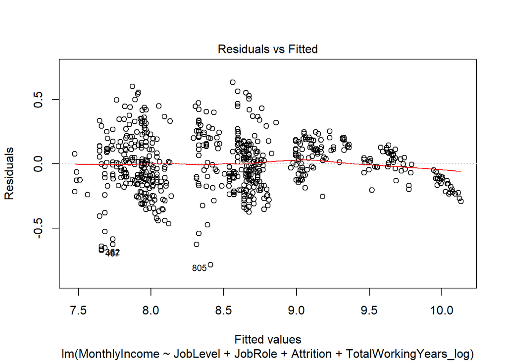

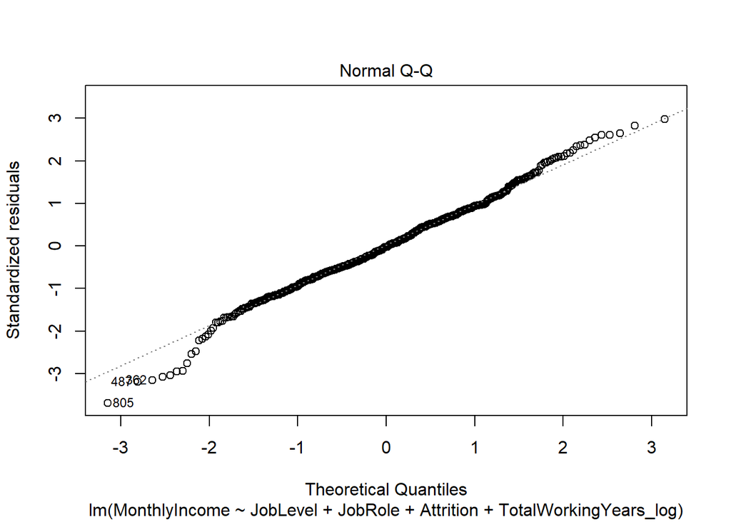

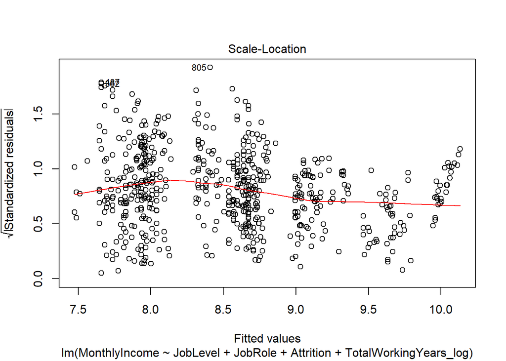

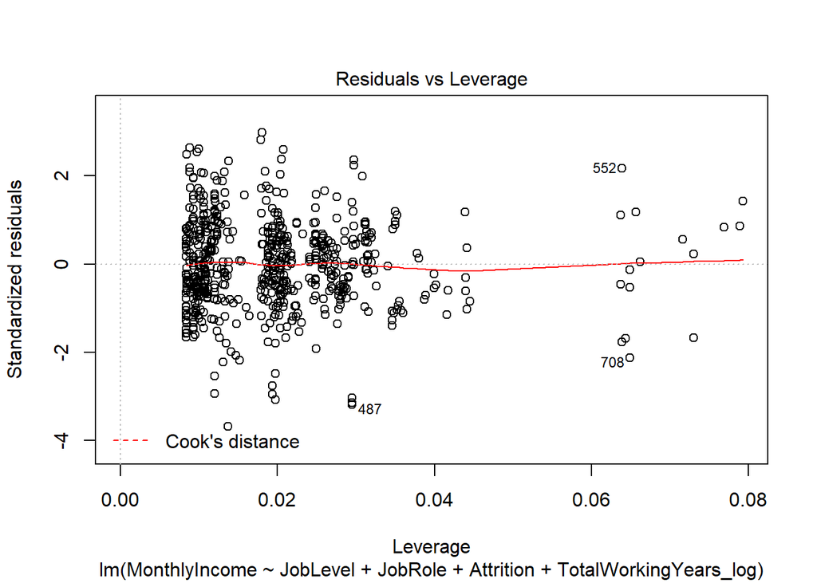

```r
plot(lm_model)
```

```r
library(tidyverse)
# http://www.sthda.com/english/articles/38-regression-model-validation/158-regression-model-accuracy-metrics-r-square-aic-bic-cp-and-more/
lm_pred <- exp(predict(lm_model, test))
score = data.frame(
  AdjR2 = (summary(lm_model)$adj.r.squared),
  RMSE = RMSE(lm_pred, exp(test$MonthlyIncome)),
  AIC =  (extractAIC(lm_model))
)

score
```

| AdjR2 | RMSE | AIC |
| --- | --- | --- |
| 0.8972983 | 1302.262 | 12.000 |
| 0.8972983 | 1302.262 | -1862.613 |

To assess the assumptions being met, we considered the following that is presinted above in the diagnostic plots: * Normality - QQ plots show the residual fitting well on linear line, some small deviations from the lower tail, but nothing to be conserned. assumption met * Independence - the data discription did not present any concerns that the data fails independence - assumption met * equal variance - after the log transformaiton on `TotalWorkingYears` provided better output in the residual v fits plot that provides indicate of equal variance. Additionally, in the leverage plot, there are no significant concerns regarding leverage and influence that could violate this assumption. While we note the leverage plot call out potential outlier, this appears to be no significant concern - assumption ment

```r
library(readxl)
salary_submission = read_excel("./data/CaseStudy2CompSet No Salary.xlsx")
salary_submission$Attrition = as.numeric(as.factor(salary_submission$Attrition))-1
salary_submission$TotalWorkingYears_log = log(salary_submission$TotalWorkingYears+0.5)

submission_pred = exp(predict(lm_model, newdata=salary_submission))
final_submission = data.table(ID=salary_submission$ID, MonthlyIncome=submission_pred)
write.table(final_submission, "./data/Case2PredictionsPhillip Salary.csv", sep=",", row.names=F)
```

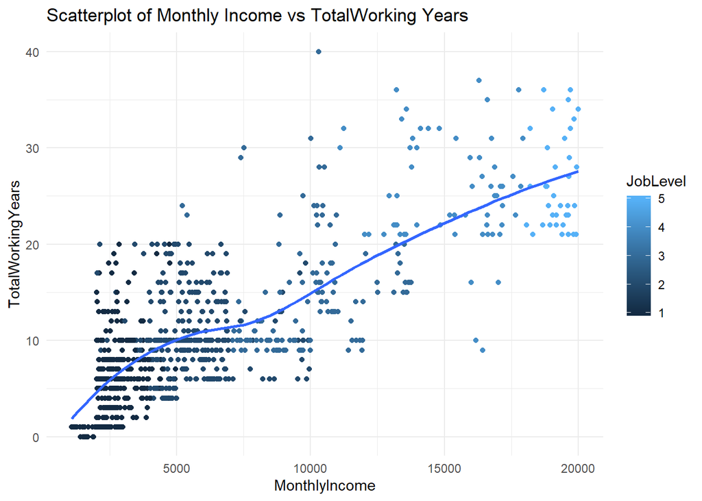

```r
gg <- ggplot(df, aes(x=exp(MonthlyIncome), y=TotalWorkingYears)) +
  geom_point(aes(col=JobLevel)) +
  geom_smooth(method="loess", se=F) +
  labs(
       y="TotalWorkingYears",
       x="MonthlyIncome",
       title="Scatterplot of Monthly Income vs TotalWorking Years")

plot(gg)
```

The scatterplot above shows a clear indicate that monthly income and Total Working years are related as well as JobLevel. Each of these are positively correlated.